# [Algorithmic Fairness](https://www.marcellodibello.com/algorithmicfairness/) – Feedback Loops

Marcello Di Bello - ASU - Fall 2021 - Week #4

Our goal is to understand how feedback loops work, focusing on predictive policing, but the concept can be generalized to other domains.

Other expressions with a similar meaning are: self-reinforcing process; vicious circle; self-fulfilling prophecy; self-referential process; compounding; multiplier; ratchet effect. Slightly different, but still closely related, are the ideas of echo chamber and ideological polarization.

Harcourt (2006), Against Prediction, [Chapter 5](https://www.tau.ac.il/law/events/15-12-06/C-Chapter5.pdf), Chicago UP

# **General ideal**

A feedback loop is a process that repeats itself through multiple iterations over time. The output of the process serves as input for the next iteration. For example, consider the application of the function $f(...)=(...)^2$ onto itself. The feedback loop takes the following form: $f(...)=(...)^2$; $f(f(...))=((...)^2)^2$; $f(f(f(...)))=(((...)^2)^2)^2$; etc. The formula for compounding, $p(1+i)^n$, is another example, where $n$ is the number of years, $i$ the interest rate, and $p$ the principal.

Compounding interest is a good feedback loop for those with money. We often think of feedback loops in a negative way, though.

## Example 1: US News’s college ranking

> U.S. News’s first data-driven ranking came out in 1988 … as the ranking grew into a national standard, a vicious *feedback loop* materialized … the rankings were self-reinforcing. If a college fared badly in U.S. News, its reputation would suffer, and conditions would deteriorate. Top students would avoid it, as would top professors … The ranking, in short, was destiny (p. 53).

> O’Neil (2016), Weapons of Math Destruction, Chapter 3.

Besides the feedback loop above, another seemed to take place:

> … college administrators … worked hard to improve each of the metrics that went into the score … when you create a model from proxies, it is far simpler for people to game it … proxies are easier to manipulate than the complicated reality they represent. (p. 53)

> Are there two feedback loops going on and feeding on one another here?

## Example 2: PredPol

Here the feedback loop leads to an exacerbation of racial inequalities. How does this work exactly? Can we unpack the mechanism?

> … a pernicious feedback loop. The policing itself spawns new data, which justifies more policing. And our prisons fill up with hundreds of thousands of people found guilty of victimless crimes. Most of them come from impoverished neighborhoods, and most are black or Hispanic. So even if a model is color blind, the result of it is anything but. In our largely segregated cities, geography is a highly effective proxy for race (p. 87).

> O’Neil (2016), Weapons of Math Destruction, Chapter 5.

## Attempting to define “feedback loop”

There are different types of feedback loops, each operating in different ways and with their own structure. Bad feedback loops seem to have in common the following:

Is anythig missing from the three items?

1. iteration of the same process multiple times
2. using outputs as inputs at the next iteration
3. departure from reality or distortion of the intended goal that worsen as the process continues to be iterated

   A feedback loop generates no learning and no progress, only the illusion of learning and progress

# **Predictive Policing**

Predictive policing can be place-based or person-based. We will focus on place-based predictive policing such as PredPol. In both instances, the goal is to predict the occurrence of crime based on historical data and deploy police resources *proactively*. The historical data used for predicting policing typically include arrests as well as citizens calls about crime incidents. One assumption of predicting policing, and of machine learning in general, is that trends in the historical data will repeat themselves in the (near) future.

PrepPol uses three predictors: past type of crime, location and time of crime.

A common criticism of predictive policing is that it does not predict crime, but rather, policing itself:

> even the best machine learning algorithms trained on police data will reproduce the patterns and unknown biases in police data. Because this data is collected as a by-product of police activity, predictions made on the basis of patterns learned from this data do not pertain to future instances of crime on the whole. They pertain to future instances of *crime that becomes known to police*. In this sense, predictive policing … is predicting future policing, not future crime.

> Lum and Isaac (2016), [To Predict and Serve?](https://rss.onlinelibrary.wiley.com/doi/full/10.1111/j.1740-9713.2016.00960.x) Significance

## Lum and Isaac’s claims

1. Illicit drug use was evenly distributed in Oakland according to estimates based on the 2011 National Survey on Drug Use and Health (NSDUH). However, drug arrests in Oakland in 2010 were heavily concentrated in poor and minority neighborhoods. So drug arrests do not reflect illicit drug use.

   See Figure 1(a) and 1(b), p. 17.
2. Suppose PredPol had been used instead of traditional policing. Drug arrests, once again, would have been concentrated in roughly the same areas. Racial disparities in drug arrest would still remain, despite drug use being evenly distributed across racial groups.

   See Figure 2(a) and 2(b), p. 18.
3. Whenever police officers are given an incentive to arrest when they patrol a neighborhood, predictions about volume of crime at future locations will even more clearly point to the neighborhoods previously singled out as crime hot spots.

   See Figure 3, p. 19.

Only the last claim is squarely about feedback loops.

## Brantingham’s response

Jeffrey Brantingham is a UCLA anthropology professor inventor of PredPol.

> In practise, the majority of hotspot and place-based predictive policing algorithms focus not on arrests, but on crimes predominantly reported to the police by the public … Thus, the goal is to send police resources to areas where crimes have been reported by victims, thus preventing future crimes in those areas. While a feedback loop for reported crime may be possible, in this case the self-reinforcement is towards places where citizens are placing calls for service (p.2).

> Brantingham et al (2018), [Does Predictive Policing Lead to Biased Arrests? Results From a Randomized Control Trial](https://www.tandfonline.com/doi/full/10.1080/2330443X.2018.1438940), Statistics and Public Policy, 5(1): 1-6. Another important study is Mohler et al (2015), [Randomized Controlled Field Trials of Predictive Policing](https://escholarship.org/uc/item/1br4975j), Journal of the American Statistical Association, 110(512): 1399-1411.

> … the analyses do not provide any guidance on whether arrests themselves are systemtically biased … The current study is only able to ascertain that arrest rates for black and Latino individuals were not impacted, positively or negatively, by using predicting policing (p. 4).

# **Simulating feedback loops in predicting policing**

More details about the simulation are available in my note on Simulating Feedback Loops in Predictive Policing

Suppose police want to learn about shares of crime from two areas, A and B. Each area contributes a certain share of crime, and the police have prior beliefs about how much crime one area contributes relative to the other. What the police believe initially need not be—and most likely will not be—correct. Police collect information about where crime is happening every day by patrolling. Suppose police patrolling correctly detects 10% of the crimes happening in an area. There are no false positives. Police update their beliefs about shares of crime by area with information from patrolling every day. Will the police eventually learn the true shares of crime by area?

**Scenario 1**: Police decide the area to patrol by flipping a weighted coin. Side A and side B of the coin have a probability corresponding to the share of crime the police believe is happening in A and B respectively. Police initially believe A contributes 20% of crime and B contributes 80%, but these beliefs are updated as police acquire more information about crime. True crime shares are 50:50. Depending on the outcome of the coin flip, police patrol one area per day. In this scenario, the police will *not learn* that crime shares are in fact 50:50 even though patrolling an area correctly detect crime at equal rates in either area.

Scenario 1 with coin flip. Police will tend to learn that the shares of crime are similar to what they originally believed. In fact, they will often enough learn that the shares of crime are more extreme than they originally believed.

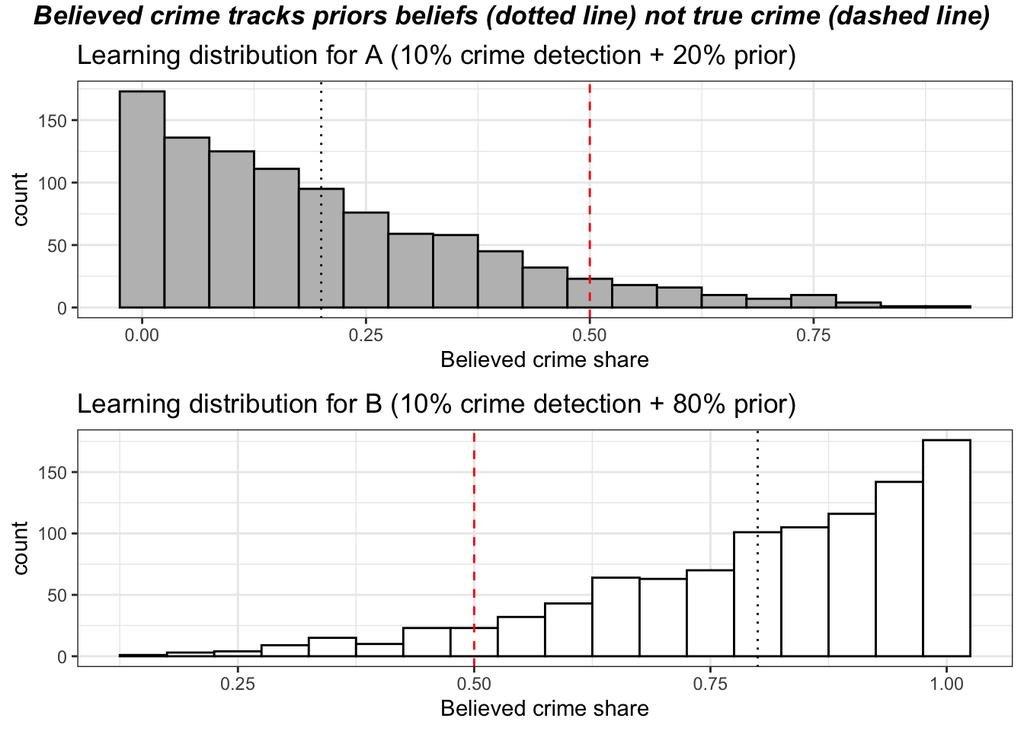

**Scenario 2**: Same as the previous scenario except that true crime shares by area are now 49:51 and police initially believe that crime is shared equally, 50:50. Police will not learn the true shares of crime by area, but in fact, form distorted beliefs that both overestimate and underestimate crime.

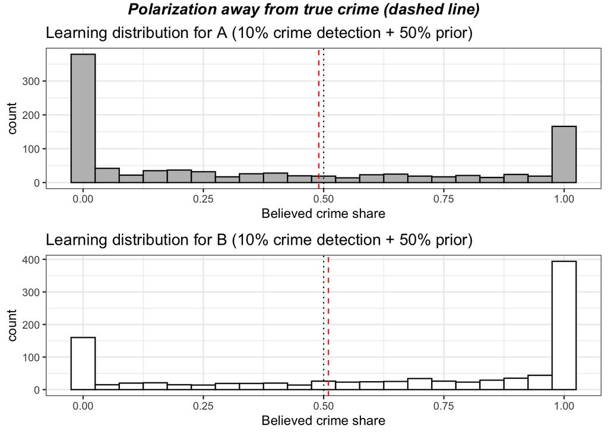

**Scenario 3**: Instead of flipping a coin, police send resources in proportion to how much crime they believe is happening in an area. They will split their presence by area accordingly. In this scenario, police will approximately learn the true shares of crime by area.

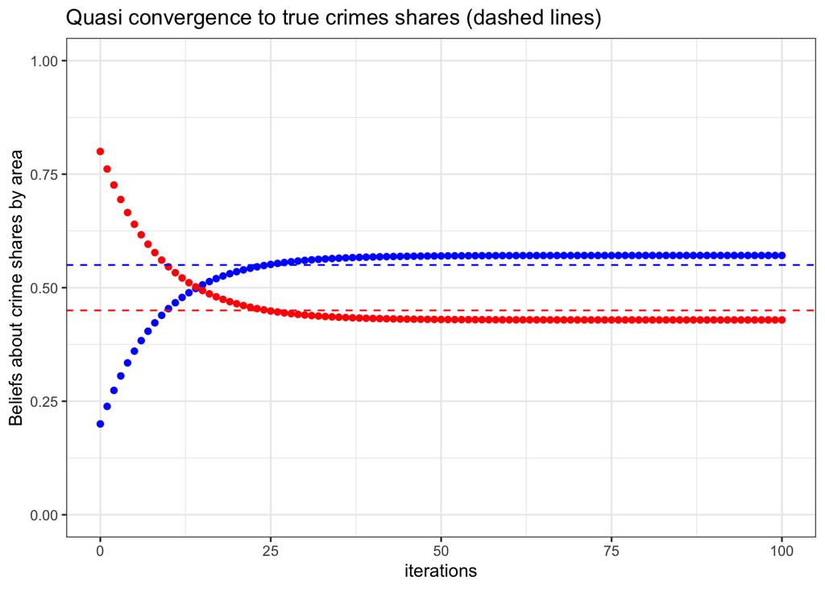